# Exploring the Impact of Class Size on First Grade Mathematics Achievement

Alireza Abolhasani Zeraatkar

03/18/2024

# 1 Abstract

This study delves into the longstanding debate surrounding the impact of class size on educational outcomes, specifically examining its effect on 1st grade students’ mathematics grades. Drawing upon the comprehensive STAR dataset, this research employs an analysis of variance (ANOVA) to scrutinize math scores across different classroom settings, including small, regular, and regular with aide configurations. Initial findings suggest a notable correlation between class size and math performance, highlighting the potential advantages of smaller class environments in enhancing student achievement. Moreover, the study addresses critical considerations regarding the economic and logistical feasibility of class-size reduction (CSR) policies. By integrating a nuanced analysis of various educational, demographic, and institutional variables, this investigation contributes to a more informed debate on optimal class sizes, aiming to offer actionable insights for educators, policymakers, and stakeholders in the educational sector.

# 2 Introduction

The intricate relationship between class size and student outcomes has long been a subject of interest within the educational landscape, provoking extensive debate and research. The seminal Student/Teacher Achievement Ratio (STAR) study, conducted in Tennessee during the late 1980s, stands as a cornerstone in this field of inquiry. This longitudinal investigation involved over 7,000 students across 79 schools, meticulously examining the impact of various class configurations—ranging from small classes and regular classes to regular classes with a teacher’s aide—on student achievement from kindergarten through third grade. Utilizing the Stanford Achievement Tests as a measure, the study sought to identify statistically significant differences in scaled student outcomes, thereby contributing to a nuanced understanding of the role class size plays in educational efficacy.

This investigation draws inspiration from the conviction, echoed by luminaries such as Einstein and Mandela, that education is a paramount force capable of transforming society and nurturing individual potential. Against this backdrop, our study aims to harness the rich dataset provided by Project STAR, exploring critical questions about the correlation between class size and math scaled scores in first grade. The implications of this exploration extend beyond academic discourse, touching on policy-making and resource allocation within the realm of education. By delving into whether and how class size variations influence student performance, this research aspires to offer evidence-based insights that could inform classroom design and teaching strategies, ultimately aiming to enhance the quality and efficiency of education systems.

Embracing a methodical approach, our analysis will employ analysis of variance statistical method to investigate potential disparities in math scaled scores of first grade students across different class types and determine which class configuration yields the highest academic achievement. This endeavor is not only a quest for academic enlightenment but also a practical examination aimed at guiding educators, policy-makers, and stakeholders in making informed decisions about class-size reduction (CSR) initiatives. As CSR represents a significant financial and logistical commitment, the findings of this study could prove pivotal in determining whether the potential benefits of such policies justify the resources invested. Through this comprehensive inquiry, we aim to contribute to the ongoing dialogue on optimizing educational practices, thereby paving the way for a more informed and effective deployment of educational resources [1].

# 3 Background

## 3.1 Variables Catalog

For the analysis presented in this project, the STAR dataset capturing various aspects of 1st-grade students, their teachers, and educational settings. To facilitate a structured analysis, we categorized the dataset’s variables into four primary groups: **Student-Related Variables, Classroom Context Variables, School-Related Variables,** and **Teacher-Related Variables**. Each category encompasses specific variables that collectively offer insights into different dimensions of the educational environment and its impact on student outcomes.

### 3.1.1 Student-Related Variables

The **Student-Related Variables** include `gender`, `ethnicity`, `lunch1`, and `math1`. These variables provide insights into the demographic profile of the students and key aspects of their academic performance:

- `gender` and `race` are categorical variables that capture the student’s gender, ethnic background/race, respectively, with specific values representing different categories (e.g., Male, Female for `gender`, and White, Black, Hispanic, Other, Asian and Native American racial groups for `race` ).
- `g1freelunch` indicates whether the first grade student qualified for free lunch, serving as an indirect measure of socio-economic status.
- `g1mathss` is a continuous variable that represents the student’s total math scaled score, providing a quantitative measure of academic achievement in mathematics.

### 3.1.2 Classroom Context Variables

The **Classroom Context Variables** include `star1` and `classsize1`, which reflect the classroom environment and its potential influence on learning:

- `g1classtype` categorizes the classroom type based on the STAR project classifications, including small, regular, and regular with aide, highlighting different instructional settings.
- `g1classsize` quantifies the number of students in the classroom, offering a measure of classroom density that can impact student learning and teacher effectiveness.

### 3.1.3 School-Related Variables

**School-Related Variables** such as `g1schid` and `g1surban` provide contextual information about the educational institution:

- `g1schid` is a unique identifier for each school, allowing for the analysis of data at the school level.
- `g1surban` classifies schools into types such as inner-city, suburban, rural, and urban, offering a perspective on the geographic and socio-economic context of the educational setting.

### 3.1.4 Teacher-Related Variables

Finally, the **Teacher-Related Variables** cover `g1tchid`, `g1tgen`, `g1trace`, `g1thighdegree`, `g1tcareer`, and `g1tyears`. These variables detail the professional and demographic characteristics of the teachers:

- `teacher_id` provides a unique identifier for each teacher, facilitating analysis of teacher-specific influences on student outcomes.
- `g1tgen` and `g1trace` describe the gender and ethnic background of the teachers.
- `g1thighdegree` and `g1tcareer` offer insights into the teacher’s highest educational attainment and their position on the career ladder, respectively, indicators of professional development.
- `g1tyears` measures the total years of teaching experience, a factor often associated with teacher effectiveness.

Through the analysis of these categorized variables, our project aims to uncover the multifaceted influences on student academic performance in the 1st grade. By examining the interplay between student demographics, classroom size and school contexts, we seek to provide a comprehensive understanding of the factors contributing to the math score of first grade students.

## 3.2 Project Design

The factors mentioned in the project STAR document are designed to ensure the credibility and unbiased nature of the experiment. These factors collectively contribute to the robustness and integrity of the STAR experiment according to Boozer et al. [2].

- **Inclusive Participation**: All schools with K-3 classes in Tennessee were invited, reducing bias from selective school participation.
- **Adequate School Size**: Schools had to be large enough to form all three class types, ensuring resource, leadership, and facility differences were controlled.
- **Broad Representation**: 79 schools across various locations participated, enhancing the experiment’s credibility through a diverse sample size.
- **Diverse Backgrounds**: Inclusion of schools from different areas minimized bias from students’ backgrounds.
- **Random Assignment**: Students and teachers were randomly assigned to classes, reducing sampling bias.
- **Ethical Standards**: The experiment adhered to confidentiality and human subjects’ research standards.
- **Equitable Services**: No child received fewer services due to the experiment, maintaining fairness.
- **Standardized Testing**: Student achievement was measured by carefully monitored standardized tests.
- **Independent Analysis**: An outside consultant performed the primary statistical analyses, providing an additional safeguard against biased results.

## 3.3 Criticism of the STAR Project: Insights and Improvements

The STAR project, renowned for its scale and design in exploring the impact of class size on student performance, faces several notable criticisms according to Gilraine et al. [3] and Archilles et al. [4] that could influence the interpretation and application of its findings:

1. **Assumption of equal variance in different groups of interest (Homoskedasticity)**: The project’s methodology, particularly the aggregation of data to class means, implicitly assumes homoskedasticity of student performance across classes. This assumption is problematic, given the inherent variance in class sizes and the socio-economic and educational diversity of the student population. Such an approach overlooks the potential for greater variance in larger classes and in classes with more heterogeneous compositions.
2. **Masking Diversity and Individual Achievement**: Aggregating data at the class level obscures the diversity within classes and individual student achievements. This reductionist approach fails to capture the nuanced ways in which students might respond to class size variations, thus limiting the depth of insights into the complex dynamics between class size and student performance.
3. **Inadequate Justification for Aggregation Strategy**: The decision to aggregate data to the class level, primarily justified by the aim to reduce computational complexity, is weak, especially considering the advancements in computational capabilities. This approach also neglects potential analytical strategies that could have offered more granular insights into the effects of class size on individual student outcomes.
4. **Teaching Quality Consistency**: The variability in teaching quality across classrooms introduces a significant confounding factor in the study. Despite efforts to ensure uniform teaching quality through in-service training, reports suggest these efforts had minimal impact on teaching practices. This inconsistency in teaching quality complicates the interpretation of how class size affects student performance, independent of teacher effectiveness.

## 3.4 Suggestions for Improvement

To address these criticisms and enhance the validity and applicability of its findings, the STAR project might consider several improvements:

1. **Refine Analytical Approaches**: Adopting more sophisticated statistical models that account for heterogeneity in student performance across different classes could provide a more accurate depiction of the impact of class size. Multilevel modeling, for instance, could accommodate variances at both the student and class levels, offering a deeper understanding of the dynamics at play.
2. **Increase Focus on Individual Data**: Shifting the focus from class averages to individual student data would allow for a richer analysis of how class size affects students with varying backgrounds, abilities, and educational supports. This approach could also facilitate the examination of how different students uniquely respond to class size variations.
3. **Reassess Data Aggregation Strategies**: Re-evaluating the rationale behind data aggregation and exploring alternative analytical methods that leverage modern computational resources could uncover more nuanced insights. This might include disaggregated analyses or the use of big data techniques to handle the complexity of individual-level data.
4. **Enhance Teaching Quality Controls**: Strengthening efforts to ensure and measure consistent teaching quality across classrooms is critical. This could involve more targeted and follow-up training, the use of peer observations and feedback, and the incorporation of teaching quality metrics into the study’s analytical framework.
5. **Incorporate Confounding Variables**: More explicitly accounting for and analyzing confounding variables such as socio-economic status, educational support at home, and cultural attitudes towards education could enrich the study’s findings. Including these variables in the analysis could help isolate the specific effects of class size from these influential factors.

By addressing the insighghts provided and implementing the aforementioned suggestions, future iterations of the STAR project or similar studies could offer more comprehensive insights into the complex relationship between class size and student performance, thereby informing more effective educational policies and practices.

# 4 Descriptive analysis

The data set is in the `.sav` format and is used from the Harvard Dataverse. I read the description to find and download the data set from Harvard dataverse. The data set is in the `.sav` format with 379 variables. However, you can easily identify teacher/class in 1st grade using the variable `g1tchid`.

```r
library("foreign")

# Load data
data <- suppressWarnings(read.spss("STAR_Students.sav", to.data.frame = TRUE))
```

The columns that we would like to keep in the Harvard Dataset are the `g1tchid` which distinguish the teachers assigned to each student. The other variable to keep is the `g1schid` which distinguish the school identifier that the student has been attending during the first grade. The other variable to keep is the `g1classtype` which depicts the class type that the student was assigned to. According to the STAR user guide the variables that are candidate to keep which represents the grade1’s math score is `g1tmathss` which represents the scaled math score.

## 4.1 Non Available data

In the following we see the proportion of the unavailable data in the main data set.

```r
library(dplyr)
```

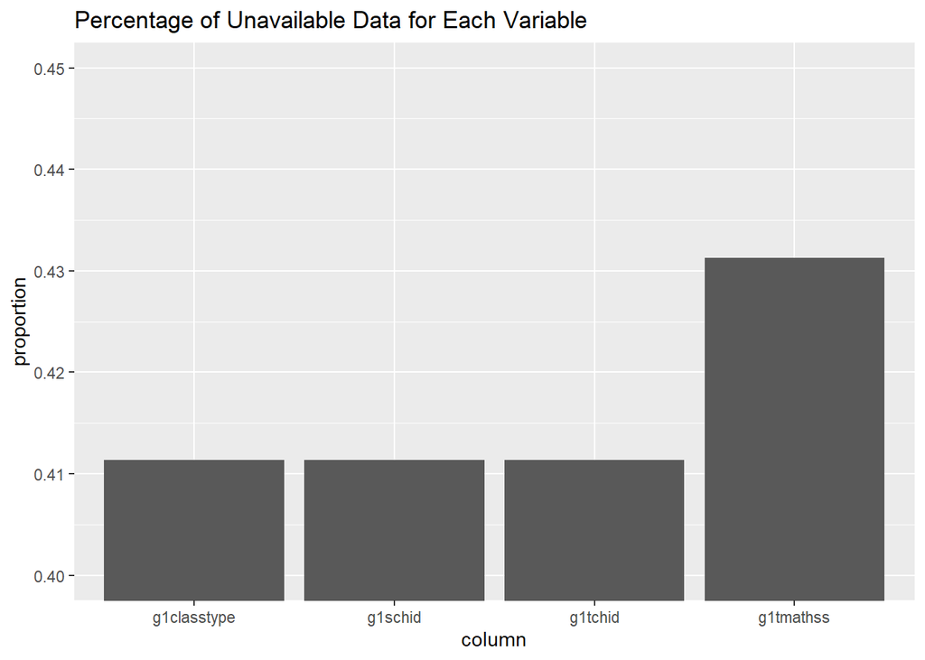

```r
library(tidyr)
library(ggplot2)
columns_to_keep <- c("g1tchid", "g1schid", "g1classtype", "g1tmathss")

df <- data %>% select(all_of(columns_to_keep))
# Calculate missing data proportions
missing_proportion <- df %>%
  summarise_all(~mean(is.na(.))) %>%
  pivot_longer(everything(), names_to = "column", values_to = "proportion")

# Plot data without styling
ggplot(missing_proportion, aes(x = column, y = proportion)) +
  geom_bar(stat = "identity") +
  ggtitle("Percentage of Unavailable Data for Each Variable") +
  coord_cartesian(ylim = c(0.4, 0.45))
```

The lack of a `g1tmathss` value indicates that certain students either didn’t participate in the testing or were not part of the STAR project in the first grade. Since these students do not fall within our target group, we will exclude these records from our analysis. Similarly, an NA in `g1tmathss` signifies that the student did not participate in any STAR classes. This group does not align with our research interests either, and thus, it’s appropriate to drop these observations as well.

## 4.2 Impact of Teacher, Class Type, and School

```r
library(dplyr)
columns_to_keep <- c("g1tchid", "g1schid", "g1classtype", "g1tmathss")


df_filtered <- df[!is.na(data$g1tmathss), ]

min_math_score <- min(df_filtered$g1tmathss)
max_math_score <- max(df_filtered$g1tmathss)
number_of_missing_scores <- nrow(df) - nrow(df_filtered)

print(paste("Range of 1st grade math scores:", min_math_score, "to", max_math_score))
```

```
## [1] "Range of 1st grade math scores: 404 to 676"
```

```r
print(paste("The number of missing scores are:", number_of_missing_scores))
```

```
## [1] "The number of missing scores are: 5003"
```

There are 11601 total observations in which 6598 observations that ranges from 404 to 676 and there are 5003 missing scores.

```r
library(ggplot2)

# Combine columns for teacher class ID. Not in use.
# Combine columns for class type. Not in use.
# Combine columns for school ID. Not in use.
library(ggplot2)
teacher_summary <- df_filtered %>%
  group_by(g1tchid, g1classtype, g1schid) %>% # Correct data grouping
  summarise(
    Min = min(g1tmathss, na.rm = TRUE),
    Mean = mean(g1tmathss, na.rm = TRUE),
    StdDev = sd(g1tmathss, na.rm = TRUE),
    Q1 = quantile(g1tmathss, 0.25, na.rm = TRUE),
    Median = median(g1tmathss, na.rm = TRUE),
    Q3 = quantile(g1tmathss, 0.75, na.rm = TRUE),
    Max = max(g1tmathss, na.rm = TRUE),
    Student_Count = n(),
    .groups = "drop" # Use 'drop' to prevent grouping
  )

head(teacher_summary)
```

| g1tchid | g1classtype | g1schid | Min | Mean | StdDev | Q1 | Median | Q3 | Max | Student_Count |
| --- | --- | --- | --- | --- | --- | --- | --- | --- | --- | --- |
| 11203804 | REGULAR + AIDE CLASS | 112038 | 446 | 486.8750 | 24.04943 | 472.0 | 479 | 510.5 | 532 | 24 |
| 11203805 | SMALL CLASS | 112038 | 444 | 499.8235 | 29.62101 | 488.0 | 505 | 518.0 | 553 | 17 |
| 11203806 | REGULAR CLASS | 112038 | 449 | 496.0370 | 30.87753 | 476.5 | 490 | 521.5 | 562 | 27 |
| 12305604 | REGULAR CLASS | 123056 | 451 | 523.7391 | 40.08198 | 495.0 | 523 | 538.0 | 612 | 23 |
| 12305605 | REGULAR + AIDE CLASS | 123056 | 488 | 532.8000 | 28.52484 | 515.0 | 526 | 562.0 | 584 | 25 |
| 12305606 | SMALL CLASS | 123056 | 493 | 534.4706 | 22.13063 | 523.0 | 532 | 549.0 | 572 | 17 |

```r
# Perform additional analysis as needed
min_math_score <- min(df_filtered$g1tmathss, na.rm = TRUE)
max_math_score <- max(df_filtered$g1tmathss, na.rm = TRUE)
number_of_missing_scores <- sum(is.na(df$g1tmathss))

print(paste("Range of 1st grade math scores:", min_math_score, "to", max_math_score))
```

```
## [1] "Range of 1st grade math scores: 404 to 676"
```

```r
print(paste("Number of missing scores:", number_of_missing_scores))
```

```
## [1] "Number of missing scores: 5003"
```

```r
head(teacher_summary)
```

| g1tchid | g1classtype | g1schid | Min | Mean | StdDev | Q1 | Median | Q3 | Max | Student_Count |
| --- | --- | --- | --- | --- | --- | --- | --- | --- | --- | --- |
| 11203804 | REGULAR + AIDE CLASS | 112038 | 446 | 486.8750 | 24.04943 | 472.0 | 479 | 510.5 | 532 | 24 |
| 11203805 | SMALL CLASS | 112038 | 444 | 499.8235 | 29.62101 | 488.0 | 505 | 518.0 | 553 | 17 |
| 11203806 | REGULAR CLASS | 112038 | 449 | 496.0370 | 30.87753 | 476.5 | 490 | 521.5 | 562 | 27 |
| 12305604 | REGULAR CLASS | 123056 | 451 | 523.7391 | 40.08198 | 495.0 | 523 | 538.0 | 612 | 23 |
| 12305605 | REGULAR + AIDE CLASS | 123056 | 488 | 532.8000 | 28.52484 | 515.0 | 526 | 562.0 | 584 | 25 |
| 12305606 | SMALL CLASS | 123056 | 493 | 534.4706 | 22.13063 | 523.0 | 532 | 549.0 | 572 | 17 |

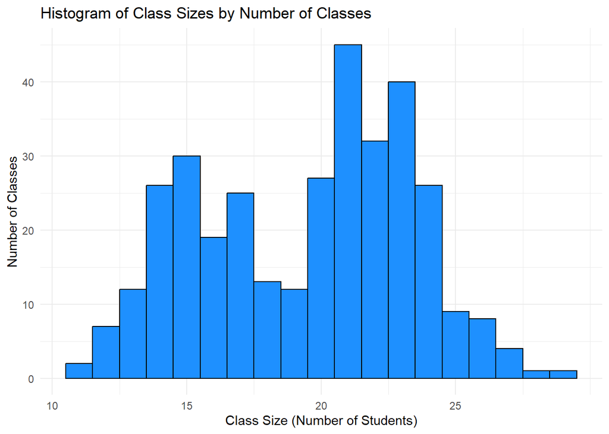

```r
ggplot(teacher_summary, aes(x = Student_Count)) +
  geom_histogram(binwidth = 1, fill = "dodgerblue", color = "black") +
  scale_x_continuous(breaks = seq(0, max(teacher_summary$Student_Count), by = 5)) +
  theme_minimal() +
  labs(title = "Histogram of Class Sizes by Number of Classes",
       x = "Class Size (Number of Students)",
       y = "Number of Classes")
```

```r
# Employ base R
number_of_unique_values <- length(unique(df_filtered$g1tmathss))

# Print the number of unique values
print(number_of_unique_values)
```

```
## [1] 67
```

I have aggregated the performance of all students’ performance across their class to obtain the summary stat to go with during the further steps of our initial analysis. As of now we have multiple option to choose from the summaries measure for each teacher to be used as the response variable.

In order to choose a summary measure, we performed a skewness test to see whether the data is slightly balanced or has significant skewness. From the following result we found the skewness of 0.16 to 0.17 for all Mean, Q1, Median, and Q3 summary measures that shows it is very slightly right skewed. We considered as the distribution of response variable to be symmetric hence we keep with the mean of math scores in grade 1 for each class as the choice of statistics.

for the consistencty in scale and visual comparison all the statistics are plotted on the same plot

```r
library(moments)

# Set up the plotting area to display four boxplots in a single row
par(mfrow=c(1, 4))

# Calculate skewness and plot boxplot for Mean
skewness_value <- skewness(teacher_summary$Mean)
print(paste("Skewness of Mean as Response Variable:", round(skewness_value, 2)))
```

```
## [1] "Skewness of Mean as Response Variable: 0.17"
```

```r
boxplot(teacher_summary$Mean, main=paste("Mean\nSkewness:", round(skewness_value, 2)), ylab="Scores", xlab="Mean")

# Calculate skewness and plot boxplot for Q1
skewness_value <- skewness(teacher_summary$Q1)
print(paste("Skewness of Q1 as Response Variable:", round(skewness_value, 2)))
```

```
## [1] "Skewness of Q1 as Response Variable: 0.17"
```

```r
boxplot(teacher_summary$Q1, main=paste("Q1\nSkewness:", round(skewness_value, 2)), ylab="Scores", xlab="Q1")

# Calculate skewness and plot boxplot for Median
skewness_value <- skewness(teacher_summary$Median)
print(paste("Skewness of Median as Response Variable:", round(skewness_value, 2)))
```

```
## [1] "Skewness of Median as Response Variable: 0.17"
```

```r
boxplot(teacher_summary$Median, main=paste("Median\nSkewness:", round(skewness_value, 2)), ylab="Scores", xlab="Median")

# Calculate skewness and plot boxplot for Q3
skewness_value <- skewness(teacher_summary$Q3)
print(paste("Skewness of Q3 as Response Variable:", round(skewness_value, 2)))
```

```
## [1] "Skewness of Q3 as Response Variable: 0.16"
```

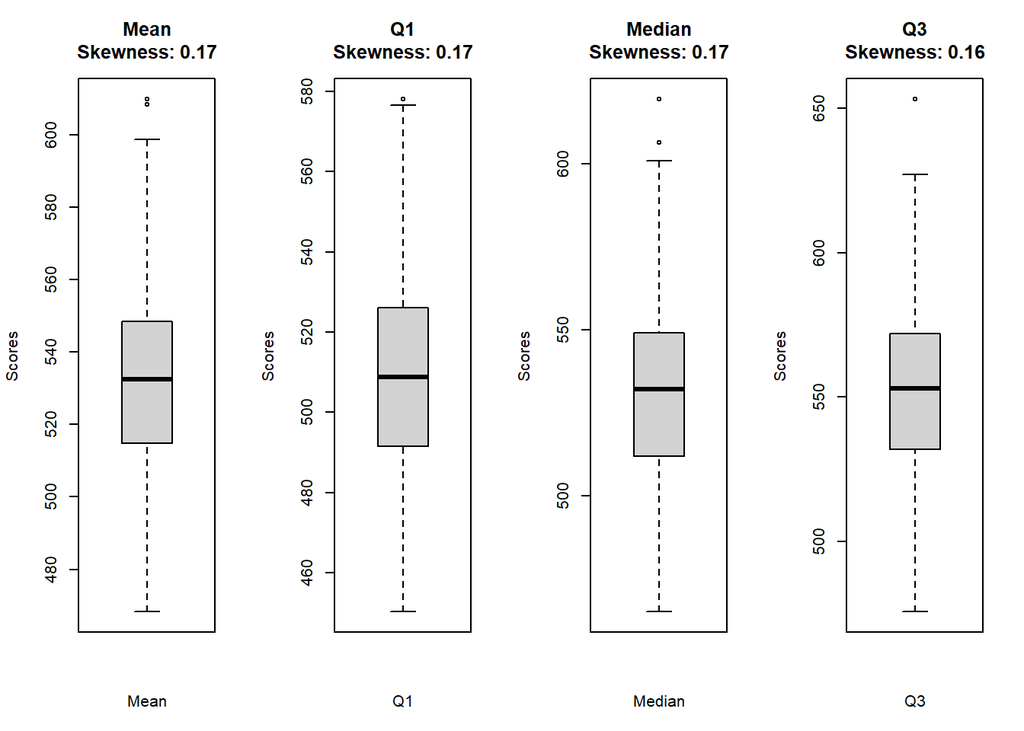

```r
boxplot(teacher_summary$Q3, main=paste("Q3\nSkewness:", round(skewness_value, 2)), ylab="Scores", xlab="Q3")
```

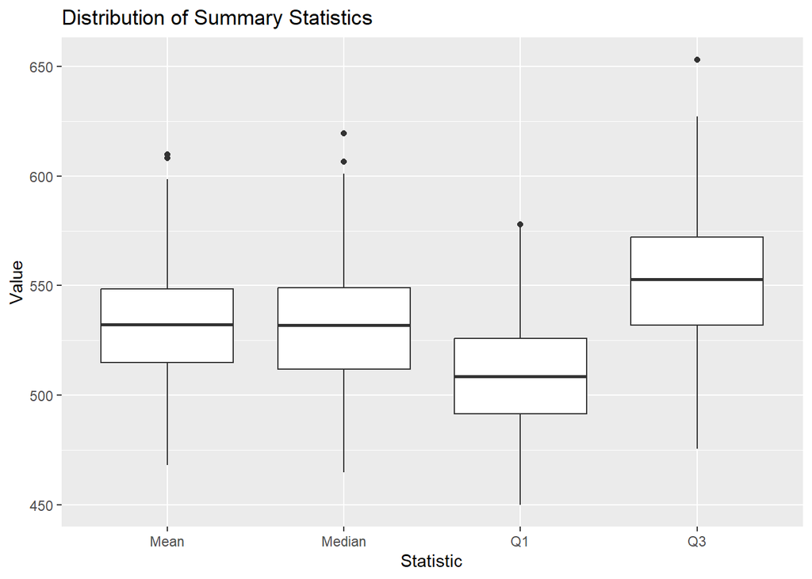

```r
library(tidyr)
library(dplyr)
library(ggplot2)

# Assuming 'teacher_summary' has been previously defined and contains the columns 'Mean', 'Q1', 'Median', 'Q3'
# Ungroup data (if previously grouped) and select only the summary statistics
long_data <- teacher_summary %>%
  ungroup() %>%
  select(Mean, Q1, Median, Q3) %>%
  pivot_longer(
    cols = everything(),
    names_to = "Statistic",
    values_to = "Value"
  )

# Now plot
ggplot(long_data, aes(x = Statistic, y = Value)) +
  geom_boxplot() +
  xlab("Statistic") +
  ylab("Value") +
  ggtitle("Distribution of Summary Statistics")
```

Here is the box plot!

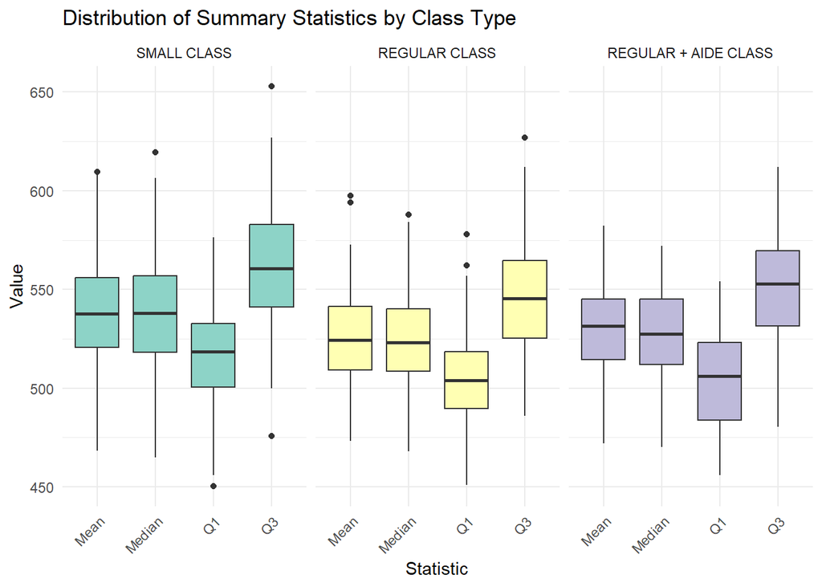

```r
library(tidyr)
library(dplyr)
library(ggplot2)

# Ensure 'teacher_summary' includes a 'class_type' column for this to work
long_data <- teacher_summary %>%
  pivot_longer(
    cols = c(Mean, Q1, Median, Q3), # Specify the summary statistics columns
    names_to = "Statistic",
    values_to = "Value",
    # Retain the 'class_type' in the reshaped data
    values_drop_na = TRUE
  ) %>%
  # This assumes you want to keep 'class_type' and it's in the data
  select(g1classtype, Statistic, Value)

# Plotting with 'class_type' as a distinguishing feature
ggplot(long_data, aes(x = Statistic, y = Value, fill = g1classtype)) +
  geom_boxplot() +
  xlab("Statistic") +
  ylab("Value") +
  ggtitle("Distribution of Summary Statistics by Class Type") +
  theme_minimal() +
  scale_fill_brewer(palette = "Set3") +
  facet_wrap(~g1classtype) +
  theme(legend.position = "none",
  axis.text.x = element_text(angle = 45, hjust = 1))
```

```r
# Detect outliers using IQR method
Q1 <- quantile(teacher_summary$Mean, 0.25)
Q3 <- quantile(teacher_summary$Mean, 0.75)
IQR <- Q3 - Q1
lower_bound <- Q1 - 1.5 * IQR
upper_bound <- Q3 + 1.5 * IQR

# Identify potential outlier
outliers <- teacher_summary[teacher_summary$Mean < lower_bound | teacher_summary$Mean > upper_bound, ]
print("Potential outliers:")
```

```
## [1] "Potential outliers:"
```

```r
print(outliers)
```

```
## # A tibble: 2 × 11
##    g1tchid g1classtype g1schid   Min  Mean StdDev    Q1 Median    Q3   Max
##      <dbl> <fct>         <dbl> <dbl> <dbl>  <dbl> <dbl>  <dbl> <dbl> <dbl>
## 1 16821404 SMALL CLASS  168214   532  608.   49.8  560.   620.   653   653
## 2 21653705 SMALL CLASS  216537   535  610.   43.8  575    606.   653   676
## # ℹ 1 more variable: Student_Count <int>
```

## 4.3 Multivariate descriptive statistics for the outcome

```r
# Load necessary library
library(readr)

# Select relevant variables for descriptive statistics
selected_vars <- teacher_summary[, c("Min", "Mean", "StdDev", "Q1", "Median", "Q3", "Max", "Student_Count")]

# Display the structure and a summary of the selected variables
str(selected_vars)
```

```
## tibble [339 × 8] (S3: tbl_df/tbl/data.frame)
##  $ Min          : num [1:339] 446 444 449 451 488 493 507 444 474 446 ...
##  $ Mean         : num [1:339] 487 500 496 524 533 ...
##  $ StdDev       : num [1:339] 24 29.6 30.9 40.1 28.5 ...
##  $ Q1           : Named num [1:339] 472 488 476 495 515 ...
##   ..- attr(*, "names")= chr [1:339] "25%" "25%" "25%" "25%" ...
##  $ Median       : num [1:339] 479 505 490 523 526 ...
##  $ Q3           : Named num [1:339] 510 518 522 538 562 ...
##   ..- attr(*, "names")= chr [1:339] "75%" "75%" "75%" "75%" ...
##  $ Max          : num [1:339] 532 553 562 612 584 572 612 545 627 567 ...
##  $ Student_Count: int [1:339] 24 17 27 23 25 17 14 20 15 21 ...
```

```r
summary(selected_vars)
```

```
##       Min             Mean           StdDev            Q1
##  Min.   :404.0   Min.   :468.3   Min.   :12.65   Min.   :450.2
##  1st Qu.:446.0   1st Qu.:514.8   1st Qu.:29.16   1st Qu.:491.5
##  Median :468.0   Median :532.4   Median :34.52   Median :508.8
##  Mean   :468.1   Mean   :531.6   Mean   :35.08   Mean   :509.4
##  3rd Qu.:486.0   3rd Qu.:548.5   3rd Qu.:40.22   3rd Qu.:526.0
##  Max.   :562.0   Max.   :609.7   Max.   :63.59   Max.   :578.0
##      Median            Q3             Max        Student_Count
##  Min.   :465.0   Min.   :475.8   Min.   :523.0   Min.   :11.00
##  1st Qu.:512.0   1st Qu.:532.0   1st Qu.:578.0   1st Qu.:16.00
##  Median :532.0   Median :553.0   Median :601.0   Median :20.00
##  Mean   :530.6   Mean   :553.3   Mean   :599.6   Mean   :19.46
##  3rd Qu.:549.0   3rd Qu.:572.0   3rd Qu.:619.5   3rd Qu.:23.00
##  Max.   :619.5   Max.   :653.0   Max.   :676.0   Max.   :29.00
```

```r
summary(selected_vars)
```

```
##       Min             Mean           StdDev            Q1
##  Min.   :404.0   Min.   :468.3   Min.   :12.65   Min.   :450.2
##  1st Qu.:446.0   1st Qu.:514.8   1st Qu.:29.16   1st Qu.:491.5
##  Median :468.0   Median :532.4   Median :34.52   Median :508.8
##  Mean   :468.1   Mean   :531.6   Mean   :35.08   Mean   :509.4
##  3rd Qu.:486.0   3rd Qu.:548.5   3rd Qu.:40.22   3rd Qu.:526.0
##  Max.   :562.0   Max.   :609.7   Max.   :63.59   Max.   :578.0
##      Median            Q3             Max        Student_Count
##  Min.   :465.0   Min.   :475.8   Min.   :523.0   Min.   :11.00
##  1st Qu.:512.0   1st Qu.:532.0   1st Qu.:578.0   1st Qu.:16.00
##  Median :532.0   Median :553.0   Median :601.0   Median :20.00
##  Mean   :530.6   Mean   :553.3   Mean   :599.6   Mean   :19.46
##  3rd Qu.:549.0   3rd Qu.:572.0   3rd Qu.:619.5   3rd Qu.:23.00
##  Max.   :619.5   Max.   :653.0   Max.   :676.0   Max.   :29.00
```

The following figure shows the boxplot of response variable spread across Y axis for each class type shown on the X axis.

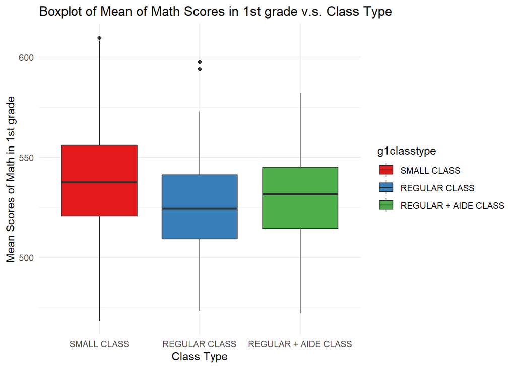

```r
library(ggplot2)

ggplot(teacher_summary, aes(x = g1classtype, y = Mean, fill = g1classtype)) +
geom_boxplot() +
labs(title = "Boxplot of Mean of Math Scores in 1st grade v.s. Class Type",
   x = "Class Type",
   y = "Mean Scores of Math in 1st grade") +
theme_minimal() +
scale_fill_brewer(palette = "Set1")
```

## 4.5 **A summary statistics of schools based on their identifier**

The Outcome v.s. school IDs is plotted based on the reported selected summary statistics

```r
# Calculate the summary statistics for each school
school_summary <- df_filtered %>%
  group_by(g1schid) %>%
  summarise(
    Min = min(g1tmathss),
    Mean = mean(g1tmathss),
    StdDev = sd(g1tmathss),
    Q1 = quantile(g1tmathss, 0.25),
    Median = median(g1tmathss),
    Q3 = quantile(g1tmathss, 0.75),
    Max = max(g1tmathss),
    Student_Count = n()
  )

head(school_summary)
```

| g1schid | Min | Mean | StdDev | Q1 | Median | Q3 | Max | Student_Count |
| --- | --- | --- | --- | --- | --- | --- | --- | --- |
| 112038 | 444 | 493.7500 | 28.39822 | 474 | 489 | 515.00 | 562 | 68 |
| 123056 | 451 | 530.0308 | 31.65881 | 505 | 529 | 549.00 | 612 | 65 |
| 128076 | 444 | 524.2714 | 39.07923 | 500 | 526 | 548.00 | 627 | 70 |
| 128079 | 456 | 517.1892 | 32.66756 | 497 | 512 | 534.25 | 592 | 74 |
| 130085 | 439 | 554.5647 | 43.62433 | 526 | 549 | 584.00 | 676 | 85 |
| 159171 | 444 | 545.2177 | 35.41084 | 523 | 545 | 562.00 | 653 | 124 |

```r
print(summary(school_summary$Mean))
```

```
##    Min. 1st Qu.  Median    Mean 3rd Qu.    Max.
##   489.4   518.0   530.6   530.4   543.0   570.7
```

as we see the median of selected outcome (math1’s score mean value) for the school summary is extremely close to the mean. (Median=530.6 , Mean = 530.4) While the Q1 and Q3 show the middle half of the outcome is spread among [518.0, 543.0] this justifies the selection of mean statistics since the distribution of data is almost non-skewed and symmetric and the number of outlier are 0.

```r
# Detect outliers using IQR method
Q1 <- quantile(school_summary$Mean, 0.25)
Q3 <- quantile(school_summary$Mean, 0.75)
IQR <- Q3 - Q1
lower_bound <- Q1 - 1.5 * IQR
upper_bound <- Q3 + 1.5 * IQR

# Identify potential outliers among school_Id s
outliers <- school_summary[school_summary$Mean < lower_bound | school_summary$Mean > upper_bound, ]
print(paste("There is", nrow(outliers), "outliars"))
```

```
## [1] "There is 0 outliars"
```

## 4.6 **Main effect plot of response variable to factors**

In the following we aim to plot the main effect vs the class type and the main effect vs the school id effect plot.

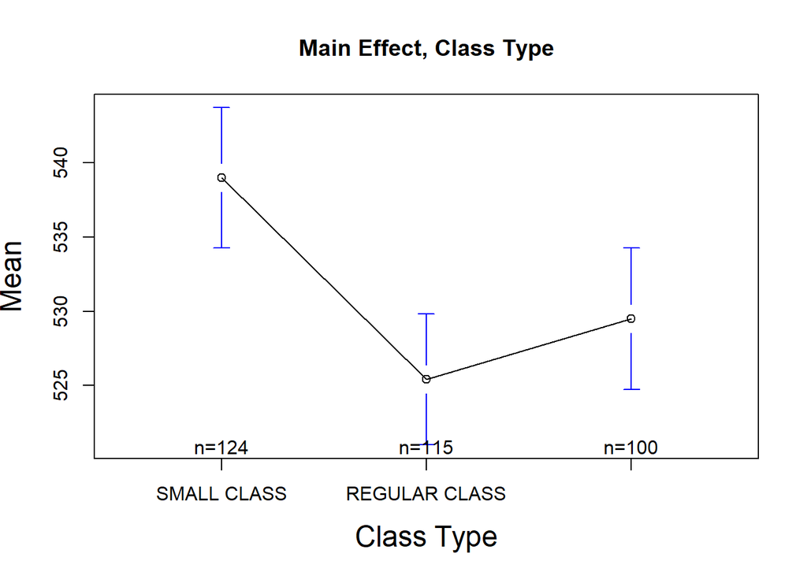

```r
library(gplots)
teacher_summary$g1classtype <- as.factor(teacher_summary$g1classtype)
teacher_summary$g1schid <- as.factor(teacher_summary$g1schid)

options(repr.plot.width=12, repr.plot.height=12)
#par(mfrow=c(3, 1))
# Main effect plot for class type
plotmeans(Mean ~ g1classtype, data=teacher_summary, xlab="Class Type", ylab="Mean",
          main="Main Effect, Class Type", cex.lab=1.5)
```

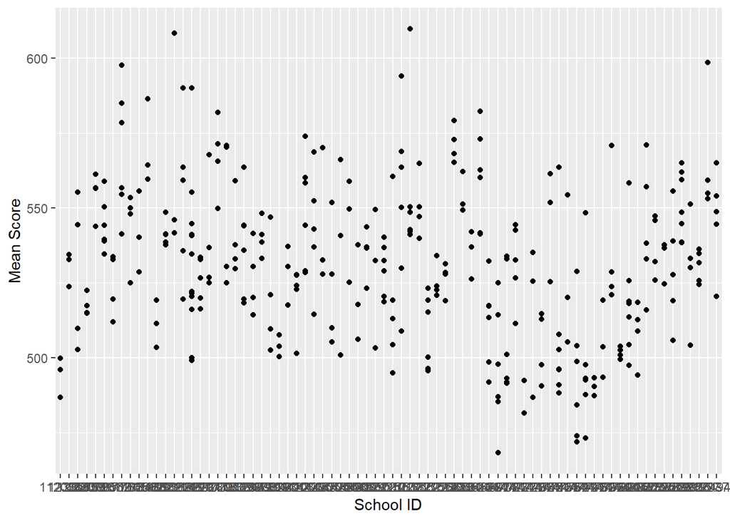

```r
library(ggplot2)

# Basic plot with proper X and Y axis titles
g2 <- ggplot(teacher_summary, aes(x = as.factor(g1schid), y = Mean)) +
  geom_point() +
  xlab("School ID") +
  ylab("Mean Score")

# Display the plot
g2
```

```r
# Assuming class_type and schoolid are suitable for an interaction plot
#interaction.plot(filtered_teacher_summary$class_type, filtered_teacher_summary$schoolid, filtered_teacher_summary$Mean,
#                 cex.lab=1.5, ylab="Mean", xlab='Class Type', leg.bty="o", xpd=TRUE, legend.pos="topright")
#par(mfrow=c(1, 1))
```

# 5 Inferential analysis

We define a two-way ANOVA model as follows $Y_{ijk} = \mu_{..} + \alpha_{i} + \beta_{j} + \epsilon_{ijk}$, where the index $i$ represents the class type: small ($i=1$), regular ($i=2$), regular with aide ($i=3$), and the index $j$ represents the school indicator. The error terms ${\epsilon_{ij}}$ are I.I.D and follow $N(0,\sigma^2)$ with equal variance and in dependency of each error term and the normal distribution.

The $\mu_{..}$ is the overall mean which represents the grand mean among all the observations. The $\alpha_i$ is the effect of the class type (where i=1 is small, i=2 is regular and i=3 is regular with aide) on the $Y_{ijk}$ or outcome. In other word, it tells us how the class size affects the outcome, relative to the $\mu_{..}$ . The $\beta_j$ is the effect of the j(st,nd,th) school onto the $Y_{ijk}$. in other word, it tells us the variation in $Y_{ijk}$ which is different among the schools. The $\epsilon_{ijk}$ is the error term of every single observation that we have, it represents the random deviation of each observation from the two-way ANOVA model which couldn’t be explained by either one of the class types or school. The assumption is the error term $\epsilon_{ijk}$ is i.i.d and is distributed with $N(\mu=0,\sigma^2)$ where the variance is constant.

## 5.1 **The factor effect definition**

$\mu_{..} = \sum_{i=1}^{3}\sum_{j=1}^{76}\mu_{ij}/(3*76), \mu_{i.} = \sum_{j=1}^{76}\mu_{ij}/76, \mu_{.j}=\sum_{i=1}^{3}\mu_{ij}/3$ and $\alpha_{i} = \mu_{i.}-\mu_{..}, \beta{j} = \mu_{.j} - \mu_{..}$

The constraints on the defined two-way ANOVA model are on the parameters of $\alpha_i$ and $\beta_j$ where we have the following two constraints.

## 5.2 **Assumptions on the proposed model**

First: $\sum_{i=1}^{3}\alpha_i = 0$ and Second: $\sum_{i=1}^{76}\beta_j = 0$ since that there are three types of classes and 76 different school indicators which shows the average effect of class type and the average effect of the schools should cancel out themselves in other words, any effect should be measured while compared against the $\mu_{..}$ .

To justify the choice of Two-Way ANOVA model, we are assuming that the outcome is variable of both additive effect of the class type and the school, please note that this the initial assumption and during the course of the project it’s probable to find the assumption doesn’t hold. It’s important to note that prior to the experiment setup, only the eligible schools could participate in the experiment, those who willed to assign students randomly to the different type of classes and those who could provide at least one of each class type.

In this model we dropped all interaction terms for the benefit of model effectiveness and less number of parameters with unknown values. However, we do not reject the possibility of existence of interaction terms between the school identifier and class type in the reality. In this case it is rational that there shouldn’t be any effect of the class type at each school on the outcome is independent of each school. To rephrase, we are expecting the affect of the class type is consistent among all schools so in this case no interaction term is required. However, we use two-way ANOVA model since we want to explain the outcome by the additive effect of both class type and school.

Since the interaction terms are dropped, to reduce the number of unknown parameters, we need to state additional assumptions which could be rejected in the real scenarios. We assume that all the $\epsilon_{ijk}$ are identically distributed and independent and follow Normal distribution, they all have equal variance of a constant value.

Given that the data for each observation is aggregated based on different number of students in each class and is imbalanced and the fact that we are not interested in the interaction terms as mentioned above, let’s go with type II since it’s much more appropriate with the unbalanced data that two-way ANOVA model.

```r
suppressWarnings(library(car))
teacher_summary$g1classtype <- gsub("\\+", "and", teacher_summary$g1classtype)
# The plus sign will introduce computational bugs in the ANOVA, hence replaced!

lm_model <- lm(Mean ~ factor(g1schid) + factor(g1classtype), data = teacher_summary)
anova_result <- Anova(lm_model, type = 2)

anova_result
```

|  | Sum Sq | Df | F value | Pr(>F) |
| --- | --- | --- | --- | --- |
| factor(g1schid) | 136832.53 | 75 | 6.593013 | 1.170721e-30 |
| factor(g1classtype) | 12026.26 | 2 | 21.729836 | 1.866166e-09 |
| Residuals | 72224.52 | 261 | NA | NA |

```r
lm_model$coefficients[c(2,3)]
```

```
## factor(g1schid)123056 factor(g1schid)128076
##              36.09138              31.71772
```

## 5.3 **Hypothesis statement and testing**

In order to check whether any association between the class type and the mean of the first grade students’ math score exists, we will be testing the difference of the response variable across all three class types and school identifiers separately:

### 5.3.1 **Hypothesis Factor A: for association response variable to class type**

If the response variable is same for each class type then the null hypothesis $H_{0C}$ is true, otherwise if there is an inequality of response variable across any class types, then the null hypothesis $H_{0C}$ is rejected and the alternative hypothesis $H_{1C}$ is true. The null hypothesis is : $H_{0C}: \alpha_i = 0$ for all $i$ s in the class types while the alternative hypothesis is: an $i$ exists in the class types such that $H_{1C}: \alpha_i \ne 0$

We use F-test with the significance level $1-\alpha$ set to 0.95 for testing hypothesis. We will reject the null hypothesis at the given significance level if the $F^* > F(1-\alpha, r_{types}-1, n_T-r_{types})$ Where $r_{types}$ denotes all possible types of classes and $n_T$ denotes number of observations

### 5.3.2 **Hypothesis Factor B: for association response variable to school id**

If the response variable is same for each school id then the null hypothesis $H_{0S}$ is true, otherwise if there is an inequality of response variable across any school ids, then the null hypothesis $H_{0S}$ is rejected and the alternative hypothesis $H_{1S}$ is true. The null hypothesis is : $H_{0S}: \beta_j = 0$ for all $j$ s in the school ids while the alternative hypothesis is: an $j$ exists in the school ids such that $H_{1S}: \beta_j \ne 0$

We use F-test with the significance level $1-\alpha$ set to 0.95 for testing hypothesis. We will reject the null hypothesis at the given significance level if the $F^* > F(1-\alpha, r_{types}-1, n_T-r_{types})$ Where $r_{types}$ denotes all possible ids of schools and $n_T$ denotes number of observations

## 5.4 **Evaluating the** Hypothesizes

We set the significance level $1-\alpha$ to 0.95 for testing hypothesis. We will reject the null hypothesis at the given significance level for both $H_{0C}$ and $H_{0S}$ if the $F^* > F(1-\beta, r_{types/ids}-1, n_T-r_{types/ids})$

```r
# Assuming filtered_teacher_summary is your data frame with class_type, schoolid, and Mean
alpha = 0.05
# Fit models
model_full <- lm(Mean ~  g1schid + g1classtype   , data = teacher_summary) # Full model without interaction
model_class_type <- lm(Mean ~ g1classtype, data = teacher_summary) # Only class type
model_schoolid <- lm(Mean ~ g1schid, data = teacher_summary) # Only school id
model_null <- lm(Mean ~ 1, data = teacher_summary) # Null model

# Calculate Residual Sum of Squares (RSS)
RSS_full <- sum(resid(model_full)^2)
RSS_class_type <- sum(resid(model_class_type)^2)
RSS_schoolid <- sum(resid(model_schoolid)^2)
RSS_null <- sum(resid(model_null)^2)

# Type II SS for main effects
SS_class_type_Type_II <- RSS_null - RSS_class_type - (RSS_full - RSS_schoolid)
SS_schholid_Type_II <- RSS_null - RSS_schoolid - (RSS_full - RSS_class_type)

# Corrected Mean Squares
MS_classtype <- SS_class_type_Type_II / anova(model_full)$Df[2] # class type degrees of freedom from full model
MS_schoolid <- SS_schholid_Type_II / anova(model_full)$Df[3] # school id degrees of freedom from full model
MS_error <- RSS_full / model_full$df.residual

# F values
F_classtype <- MS_classtype / MS_error
F_schoolid <- MS_schoolid / MS_error

# Print results
print("*******************")
```

```
## [1] "*******************"
```

```r
#cat("Type II SS for Factor class type:", SS_class_type_Type_II, "\n")
#cat("Type II SS for Factor school id:", SS_schholid_Type_II, "\n")


# Repeat the process for Factor B with its respective degrees of freedom and calculated F-value
critical_factor_class_type <- qf(1 - alpha, anova(model_full)$Df[2], model_full$df.residual)

cat("F-value for Factor class type:", F_classtype, "\n")
```

```
## F-value for Factor class type: 42.7207
```

```r
cat("F dist. value for class types", critical_factor_class_type, "\n")
```

```
## F dist. value for class types 3.030382
```

```r
# Decision for Factor class type
if(F_classtype > critical_factor_class_type) {
  cat("Reject the null hypothesis for factor class type: It has a significant effect.\n")
} else {
  cat("Do not reject the null hypothesis for factor class type: It does not have a significant effect.\n")
}
```

```
## Reject the null hypothesis for factor class type: It has a significant effect.
```

```r
print("*******************")
```

```
## [1] "*******************"
```

```r
# Repeat the process for factor school id with its respective degrees of freedom and calculated F-value
critical_factor_schoolid <- qf(1 - alpha, anova(model_full)$Df[3], model_full$df.residual)

cat("F-value for Factor school id:", F_schoolid, "\n")
```

```
## F-value for Factor school id: 3.783425
```

```r
cat("F dist. value for school ids", critical_factor_schoolid, "\n")
```

```
## F dist. value for school ids 1.226297
```

```r
# Decision for Factor school id
if(F_schoolid > critical_factor_schoolid) {
  cat("Reject the null hypothesis for factor school id: It has a significant effect.\n")
} else {
  cat("Do not reject the null hypothesis for factor school id: It does not have a significant effect.\n")
}
```

```
## Reject the null hypothesis for factor school id: It has a significant effect.
```

```r
print("*******************")
```

```
## [1] "*******************"
```

## 5.5 **Class Type Matters!**

Based on the positive answer to the first question we will answer the second question of interest to find the associated type of class with the highest average of math scores for first grade students.

## 5.6 **Who Ace the Math?**

To answer which class type is associated with the highest math scaled scores in 1st grade, we employed the Tukey’s range test as follow: According to the Tukey’s HSD test, the small - regular and small - regular with aid has the least difference in the adjacent p values, which means the type of class of small has the highest impact on the response variable. We used the Tukey-Kramer algorithm to compare each class types mean. The confidence interval for difference of means is set to $1-\alpha = 0.95$ where $HSD = q_{\alpha}(k, N-k) \sqrt{\frac{MSE}{2} \left( \frac{1}{n_i} + \frac{1}{n_j} \right)}$ and $HSD$ is the Honestly Significant Difference and the $q_{\alpha}(k, N-k)$ is the critical value from the Tukey distribution for $\alpha$ significance level, $k$ groups, and $N-k$ degrees of freedom for the error term. The $MSE$ is the Mean Square Error from the ANOVA and the $n_i$ and the $n_j$ are the sample sizes of the $i^{th}$ and $j^{th}$ groups, respectively. $N$ is the total number of observations across all groups and $k$ is the total number of groups.

```r
tukey_results <- TukeyHSD(aov(lm_model))

tukey_results_classtype <- TukeyHSD(aov(Mean ~ g1classtype + g1schid, data=teacher_summary), which = "g1classtype")

print(tukey_results_classtype)
```

```
##   Tukey multiple comparisons of means
##     95% family-wise confidence level
##
## Fit: aov(formula = Mean ~ g1classtype + g1schid, data = teacher_summary)
##
## $g1classtype
##                                           diff       lwr       upr     p adj
## REGULAR CLASS-REGULAR and AIDE CLASS -4.094623 -9.456071  1.266825 0.1715156
## SMALL CLASS-REGULAR and AIDE CLASS    9.485401  4.215226 14.755575 0.0000909
## SMALL CLASS-REGULAR CLASS            13.580024  8.503681 18.656367 0.0000000
```

Below, we see the the differences in mean levels of class-wise on a 95% confidence level.

```
##   Tukey multiple comparisons of means
##     95% family-wise confidence level
##
## Fit: aov(formula = Mean ~ g1classtype + g1schid, data = teacher_summary)
##
## $g1classtype
##                                           diff       lwr       upr     p adj
## REGULAR CLASS-REGULAR and AIDE CLASS -4.094623 -9.456071  1.266825 0.1715156
## SMALL CLASS-REGULAR and AIDE CLASS    9.485401  4.215226 14.755575 0.0000909
## SMALL CLASS-REGULAR CLASS            13.580024  8.503681 18.656367 0.0000000
```

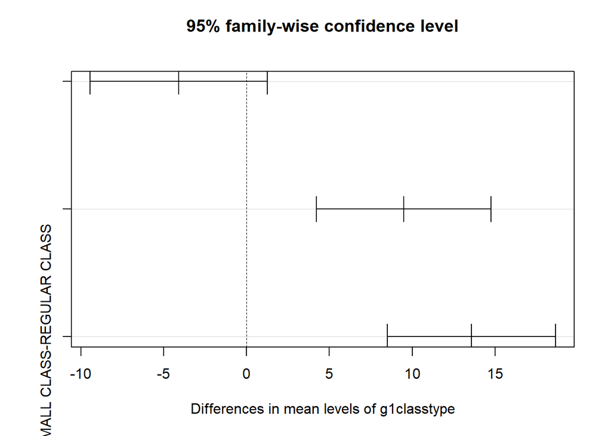

```r
plot(print(tukey_results_classtype))
```

# 6 Sensitivity analysis

## 6.1 **Testing for assumptions of error terms, potential outliers**

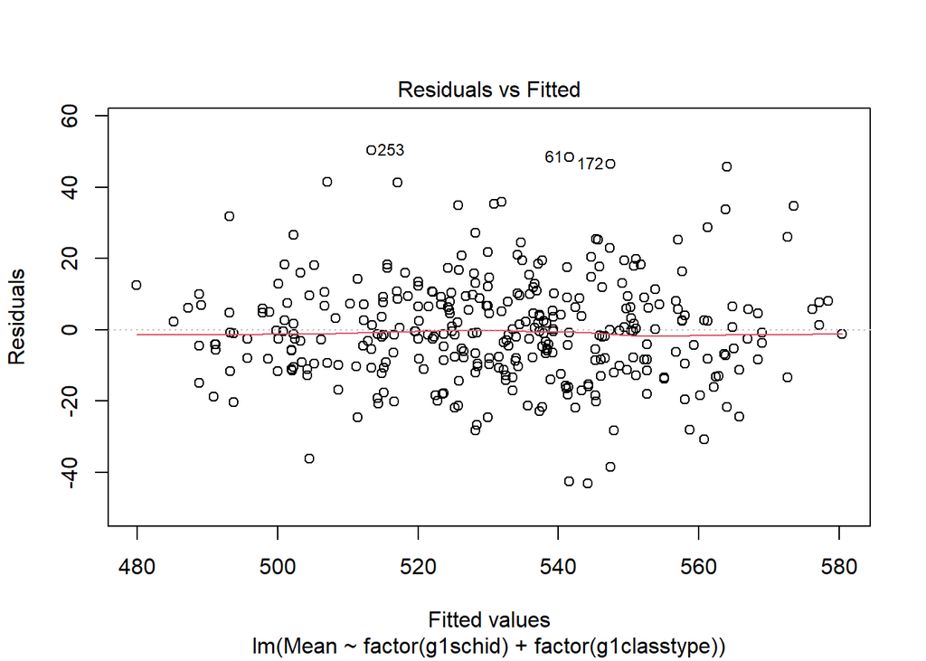

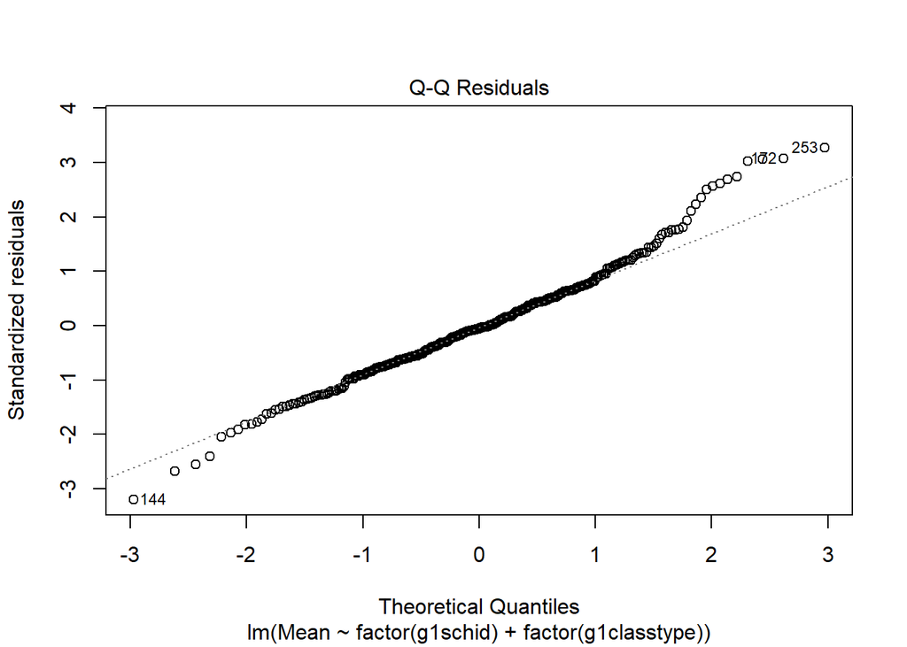

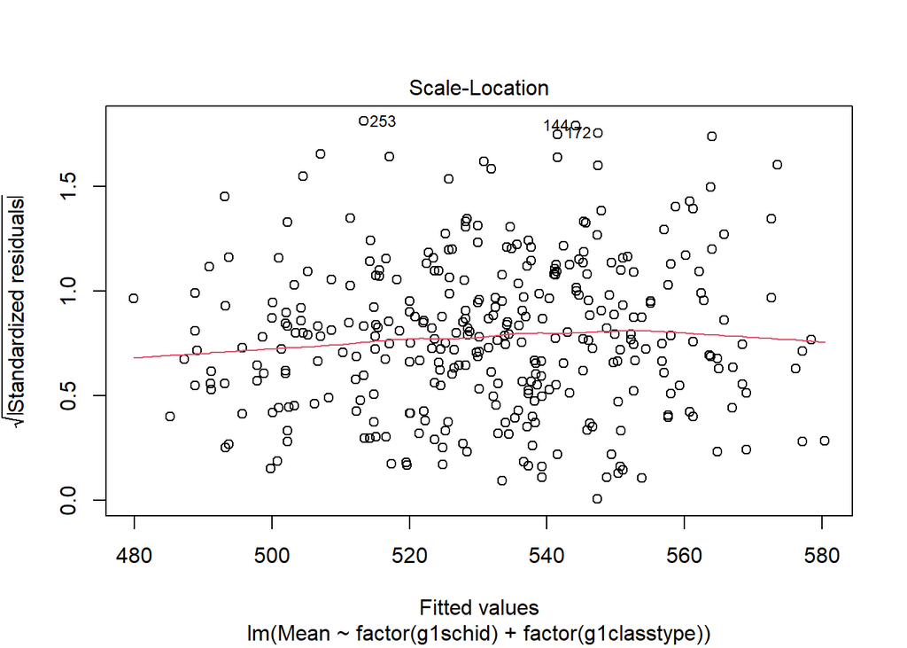

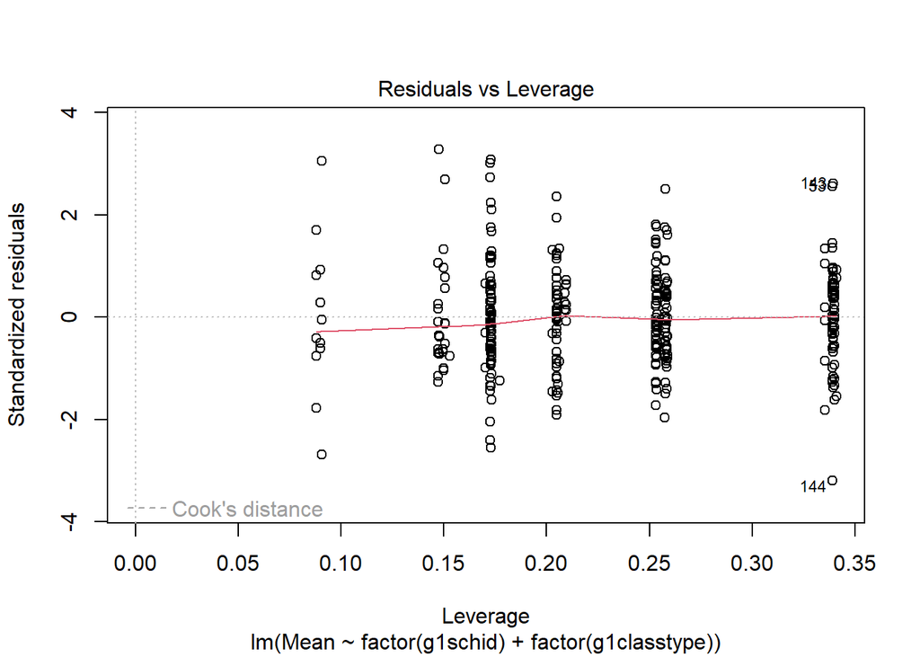

```r
# Fitted model
lm_model <- lm(Mean ~ factor(g1schid) + factor(g1classtype), data = teacher_summary)

# 1. Residuals vs Fitted
# 2. Normal Q-Q
# 3. Scale-Location (also known as Spread-Location or sqrt(|Residuals|) vs Fitted)
# 4. Residuals vs Leverage that helps us to find influential cases if any

plot(lm_model) # Diagnostic plots
```

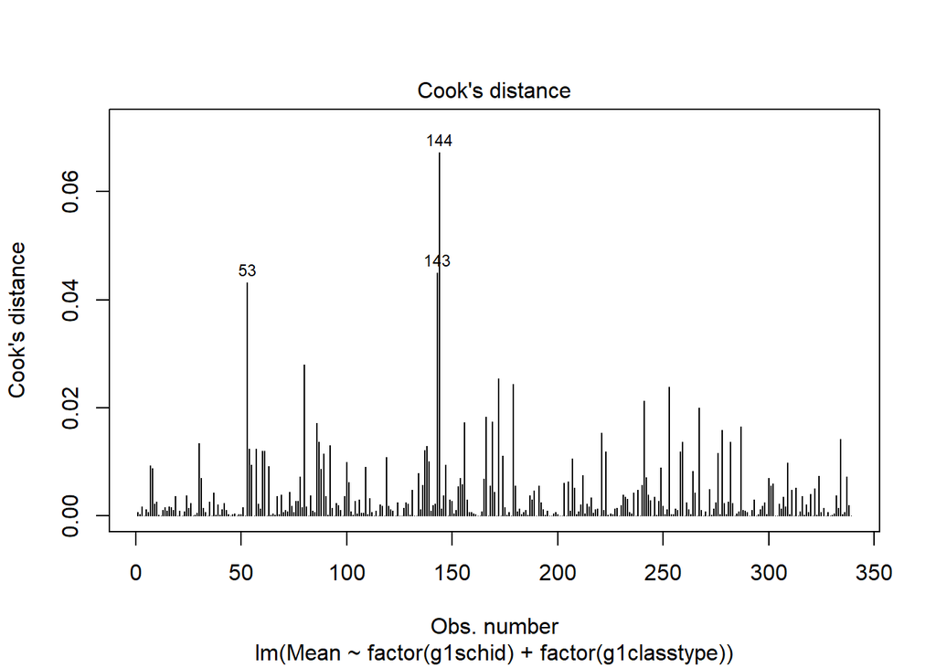

```r
plot(lm_model, which = 4) # Cook's distance plot
abline(h = 0.5, col = "red", lty=2) # Adding a reference line at 0.5 for Cook's distance (threshold can vary)
```

## 6.2 **Testing for equal variance assumption**

We assumed that the variance of error terms are equal, and we could prove that by checking the residual plot above. However to test that variance across each group is equal we test that using the null hypothesis of Levene test.

### 6.2.1 **Equal variance across class types**

The null hypothesis is $H_0: \sigma^2_1 = \sigma^2_2 = \sigma^2_3$ while the alternative hypothesis for the Levene test says $H_1 : \sigma_i^2 \ne \sigma_j^2$ for two different class types of $i$ and $j$. We use the F stat by fitting a simple anova model on each class type. We aim to find the $Z_{ij} = Y_{ij} - \bar{Y_{i.}}$ as the $Y_{i.}$ is the class type’s group median. We will fit the $Z_{ij}$ values as the response while the class type will be as the factor. If the $F^* > F(1-\alpha, r-1,n_T -1)$ then the null hypothesis $H_0$ will be rejected. Please note $r$ here stands for the number of class types.

```r
cat("Performing Levene test for class types")
```

```
## Performing Levene test for class types
```

```r
leveneTest(Mean~factor(g1classtype),data=teacher_summary)
```

|  | Df | F value | Pr(>F) |
| --- | --- | --- | --- |
| group | 2 | 0.6076908 | 0.5452045 |
|  | 336 | NA | NA |

As we see the `p-value` for class type categorical group suggest the existence of homogeneity variance across the class type groups under the significance level $1-\alpha = 0.95$ Hence the variance assumption holds true.

### 6.2.2 **Equal variance across school identifiers**

The null hypothesis is $H_0: \sigma^2_1 = \sigma^2_2 = \cdots = \sigma^2_{76}$ while the alternative hypothesis for the Levene test says $H_1 : \sigma_i^2 \ne \sigma_j^2$ for two different school identifiers of $i$ and $j$. We use the F stat by fitting a simple anova model on each school identifier. We aim to find the $Z_{ij} = Y_{ij} - \bar{Y_{.j}}$ as the $Y_{.j}$ is the school identifiers’ group median. We will fit the $Z_{ij}$ values as the response while the school identifier will be as the factor. If the $F^* > F(1-\alpha, r-1,n_T -1)$ then the null hypothesis $H_0$ will be rejected. Please note $r$ here stands for the number of school identifiers.

```r
cat("Performing LEvene test for school ids")
```

```
## Performing LEvene test for school ids
```

```r
leveneTest(Mean~factor(g1schid),data=teacher_summary)
```

|  | Df | F value | Pr(>F) |
| --- | --- | --- | --- |
| group | 75 | 0.8775795 | 0.7457615 |
|  | 263 | NA | NA |

As we see the `p-value` for school identifier categorical group suggest the existence of homogeneity variance across the school identifier groups under the significance level $1-\alpha = 0.95$ Hence the variance assumption holds true.

## 6.3 **Testing for no interaction terms assumption**

We test for interactions to see if there is any change to the assumptions that needs to be made. The null hypothesis is $H_0 : \alpha_i\beta_j = 0$ for all $i$ and $j$ in class type and schoolid. While for the alternative hypothesis we need to say there exist an $i$ and $j$ such that $H_1: \alpha_i\beta_j \ne 0$. To test the hypothesis we use the following table.

This means that the null hypothesis that stated that the interaction terms do not significantly improve the model’s fit to the data, cannot be rejected. Hence adding interaction terms between factor class type and school id to the model does not provide a statistically significant improvement in explaining the variability of Mean.

```r
# Test for interactions
full_model=lm(Mean~as.factor(g1classtype)*as.factor(g1schid),data=teacher_summary);
reduced_model=lm(Mean~as.factor(g1classtype)+as.factor(g1schid),data=teacher_summary);
anova(reduced_model,full_model)
```

|  | Res.Df | RSS | Df | Sum of Sq | F | Pr(>F) |
| --- | --- | --- | --- | --- | --- | --- |
| 1 | 261 | 72224.52 | NA | NA | NA | NA |
| 2 | 115 | 33506.60 | 146 | 38717.92 | 0.9101785 | 0.7056145 |

```r
# Fit the chosen model:
library(stats)
sig.level=0.05;
anova.fit<-aov(rank(Mean)~g1classtype+g1schid,data=teacher_summary)
summary(anova.fit)
```

```
##              Df  Sum Sq Mean Sq F value   Pr(>F)
## g1classtype   2  164742   82371  20.680 4.61e-09 ***
## g1schid      75 2042132   27228   6.836  < 2e-16 ***
## Residuals   261 1039614    3983
## ---
## Signif. codes:  0 '***' 0.001 '**' 0.01 '*' 0.05 '.' 0.1 ' ' 1
```

# 7 Discussion

## 7.2 Findings in the inferential analysis

An important takeaway from these investigations is the acknowledgment of the limitations and challenges faced, which underscores the complexity of educational research. The variability in class sizes, the urbanicity of schools, and the heterogeneity of student populations require careful consideration in the analysis and interpretation of data. For instance, the potential underrepresentation of urban settings or the economic implications of implementing smaller class sizes present practical challenges that need to be balanced against the educational benefits observed.

## 7.3 Suggestions for future research

Future research directions suggested by these analyses include a deeper exploration of the optimal class size, the impact of additional teacher aides, and the broader examination of educational outcomes beyond first-grade math scores. The suggestion to investigate the presence of additional teacher aides as a means to improve student-teacher ratios and potentially enhance test scores offers a promising avenue for further study. Moreover, extending the scope to include other factors such as household income or parental education levels could provide a more comprehensive understanding of the influences on student performance.

## 7.4 Caveats of the current analysis

we consolidate and discuss these caveats to offer a comprehensive understanding of the nuances involved in our analysis.

### 7.4.1 Noncompliance and Selection Bias

Our analysis encountered potential noncompliance, where the random assignment of students to class types might not have been strictly adhered to. This introduces a selection bias, particularly if students who switched to smaller classes were inherently different in their potential to score on tests. This bias could lead to an underestimation of the positive impact of small class sizes on student performance. Future studies should seek to understand the reasons behind such switches to better account for this bias.

### 7.4.3 Potential Violation of Stable Unit Treatment Value Assumption (SUTVA)

Our model’s assumption that each student’s outcome is independent of the treatment assignments of their peers may be violated due to peer effects, especially in the context of classroom settings. This violation suggests a need for caution in interpreting our results and possibly for developing models that can account for such interdependencies.

### 7.4.4 Extreme Distributions and ANOVA Assumptions

Some variables in our dataset exhibited extreme distributions, challenging several assumptions underlying our ANOVA models. This limitation hindered further exploration of potential influences, such as the effect of teacher experience or the broader impact of ethnicity on test scores, underscoring the importance of employing flexible models that can accommodate real-world data complexities.

### 7.4.5 Economic and Practical Considerations

The economic implications of reducing class sizes, given the significant costs associated with such interventions, present a critical caveat. Our analysis suggests benefits to smaller class sizes but also calls for a consideration of alternative, cost-effective strategies for enhancing educational outcomes.

### 7.4.6 Scope of Investigation and Future Directions

Finally, our investigation’s narrow focus on first-grade math scores, without considering kindergarten performance or other academic subjects, limits the breadth of our conclusions. Future research should aim to provide a more holistic understanding of the educational impacts of classroom size and composition, potentially including a wider array of grade levels and subject areas.

# Acknowledgement

In the course of this project, I have utilized the Bing AI tool extensively for refining my text, ensuring grammatical accuracy, and proper punctuation. This invaluable resource has significantly expedited my writing process. Additionally, I turned to Stack Overflow for assistance with coding, given my limited proficiency in R programming.

# Reference

[1] Mosteller, F. (1995). The Tennessee study of class size in the early school grades. *The future of children*, 113-127.

[2] Boozer, M., & Cacciola, S. E. (2001). Inside the’Black Box’of Project STAR: Estimation of peer effects using experimental data. *Available at SSRN 277009*.

[3] Gilraine, M. (2020). A method for disentangling multiple treatments from a regression discontinuity design. *Journal of Labor Economics*, *38*(4), 1267-1311.

[4] Achilles, C. M. (2012). Class-Size Policy: The STAR Experiment and Related Class-Size Studies. NCPEA Policy Brief. Volume 1, Number 2. *NCPEA Publications*.